# WGCNA_ANOVA and GO analysis

## Greenyellow

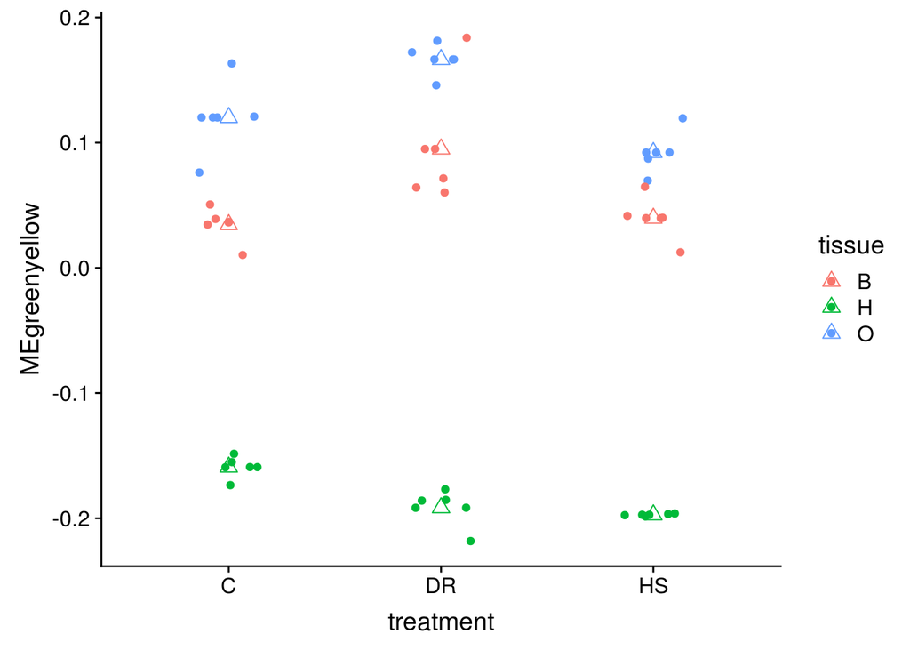

```r
all.plots[[9]]
```

```r
aov.mod_greenyellow <- aov(eg.genes[,"MEgreenyellow"] ~ phenDat.sva$treatment* phenDat.sva$tissue)
summary(aov.mod_greenyellow)
```

```
##                                          Df Sum Sq Mean Sq  F value   Pr(>F)
## phenDat.sva$treatment                     2 0.0183  0.0092   20.697 4.23e-07 ***
## phenDat.sva$tissue                        2 0.9447  0.4723 1066.587  < 2e-16 ***
## phenDat.sva$treatment:phenDat.sva$tissue  4 0.0171  0.0043    9.644 1.02e-05 ***
## Residuals                                45 0.0199  0.0004
## ---
## Signif. codes:  0 '***' 0.001 '**' 0.01 '*' 0.05 '.' 0.1 ' ' 1
```

```r
greenyellow_ph <- TukeyHSD(aov.mod_greenyellow)
greenyellow_ph
```

```
##   Tukey multiple comparisons of means
##     95% family-wise confidence level
##
## Fit: aov(formula = eg.genes[, "MEgreenyellow"] ~ phenDat.sva$treatment * phenDat.sva$tissue)
##
## $`phenDat.sva$treatment`
##              diff          lwr          upr     p adj
## DR-C   0.02474406  0.007743375  0.041744742 0.0027632
## HS-C  -0.02031358 -0.037314260 -0.003312893 0.0157392
## HS-DR -0.04505764 -0.062058319 -0.028056952 0.0000002
##
## $`phenDat.sva$tissue`
##            diff         lwr        upr p adj
## H-B -0.23907638 -0.25607707 -0.2220757     0
## O-B  0.06981172  0.05281103  0.0868124     0
## O-H  0.30888810  0.29188742  0.3258888     0
##
## $`phenDat.sva$treatment:phenDat.sva$tissue`
##                   diff          lwr          upr     p adj
## DR:B-C:B   0.060316827  0.020743785  0.099889870 0.0003298
## HS:B-C:B   0.005093649 -0.034479394  0.044666691 0.9999679
## C:H-C:B   -0.193750525 -0.233323567 -0.154177482 0.0000000
## DR:H-C:B  -0.226220394 -0.265793437 -0.186647352 0.0000000
## HS:H-C:B  -0.231847754 -0.271420796 -0.192274711 0.0000000
## C:O-C:B    0.085465853  0.045892810  0.125038895 0.0000003
## DR:O-C:B   0.131851070  0.092278028  0.171424113 0.0000000
## HS:O-C:B   0.057528703  0.017955660  0.097101745 0.0006898
## HS:B-DR:B -0.055223178 -0.094796221 -0.015650136 0.0012567
## C:H-DR:B  -0.254067352 -0.293640394 -0.214494309 0.0000000
## DR:H-DR:B -0.286537221 -0.326110264 -0.246964179 0.0000000
## HS:H-DR:B -0.292164581 -0.331737623 -0.252591539 0.0000000
## C:O-DR:B   0.025149025 -0.014424017  0.064722068 0.5055605
## DR:O-DR:B  0.071534243  0.031961201  0.111107286 0.0000154
## HS:O-DR:B -0.002788125 -0.042361167  0.036784918 0.9999997
## C:H-HS:B  -0.198844173 -0.238417216 -0.159271131 0.0000000
## DR:H-HS:B -0.231314043 -0.270887085 -0.191741000 0.0000000
## HS:H-HS:B -0.236941403 -0.276514445 -0.197368360 0.0000000
## C:O-HS:B   0.080372204  0.040799161  0.119945246 0.0000013
## DR:O-HS:B  0.126757422  0.087184379  0.166330464 0.0000000
## HS:O-HS:B  0.052435054  0.012862011  0.092008096 0.0025576
## DR:H-C:H  -0.032469870 -0.072042912  0.007103173 0.1869292
## HS:H-C:H  -0.038097229 -0.077670272  0.001475813 0.0673307
## C:O-C:H    0.279216377  0.239643335  0.318789420 0.0000000
## DR:O-C:H   0.325601595  0.286028553  0.365174638 0.0000000
## HS:O-C:H   0.251279227  0.211706185  0.290852270 0.0000000
## HS:H-DR:H -0.005627360 -0.045200402  0.033945683 0.9999314
## C:O-DR:H   0.311686247  0.272113204  0.351259289 0.0000000
## DR:O-DR:H  0.358071465  0.318498422  0.397644507 0.0000000
## HS:O-DR:H  0.283749097  0.244176054  0.323322139 0.0000000
## C:O-HS:H   0.317313606  0.277740564  0.356886649 0.0000000
## DR:O-HS:H  0.363698824  0.324125782  0.403271867 0.0000000
## HS:O-HS:H  0.289376456  0.249803414  0.328949499 0.0000000
## DR:O-C:O   0.046385218  0.006812175  0.085958260 0.0111389
## HS:O-C:O  -0.027937150 -0.067510192  0.011635893 0.3640262
## HS:O-DR:O -0.074322368 -0.113895410 -0.034749325 0.0000071
```

```r
subset(screenTab,screenTab$module=="greenyellow")
```

```
##         module size   p-val    Bonf nInTerm ont                                term name
## 81 greenyellow  165 1.0e-56 8.5e-53      36  CC                       proteasome complex
## 82 greenyellow  165 2.1e-29 1.8e-25      35  BP proteasome-mediated ubiquitin-dependent
## 83 greenyellow  165 1.4e-28 1.2e-24      35  BP    proteasomal protein catabolic process
## 84 greenyellow  165 2.6e-27 2.1e-23      15  CC                  proteasome core complex
## 85 greenyellow  165 2.1e-26 1.8e-22      15  MF    threonine-type endopeptidase activity
## 86 greenyellow  165 2.5e-25 2.1e-21      36  BP ubiquitin-dependent protein catabolic pr
## 87 greenyellow  165 4.3e-25 3.6e-21      36  BP modification-dependent protein catabolic
## 88 greenyellow  165 1.4e-24 1.2e-20      14  BP proteasomal ubiquitin-independent protei
## 89 greenyellow  165 3.9e-24 3.3e-20      16  CC           proteasome regulatory particle
## 90 greenyellow  165 1.2e-23 9.8e-20      36  BP proteolysis involved in cellular protein
```

165 genes Tissue*** treatment*** interaction*** Treatment highly sig in HS-DR, DR-C, mildly in HS-C Tissue higly sig in all comparisons Interaction highly sig in 29 diet-tissue contrasts (B&O low in C, high in DR & low in HS; H higher in C than other diets) GO: proteasome catabolic, ubiquitin processes

## Grey module - unassigned genes

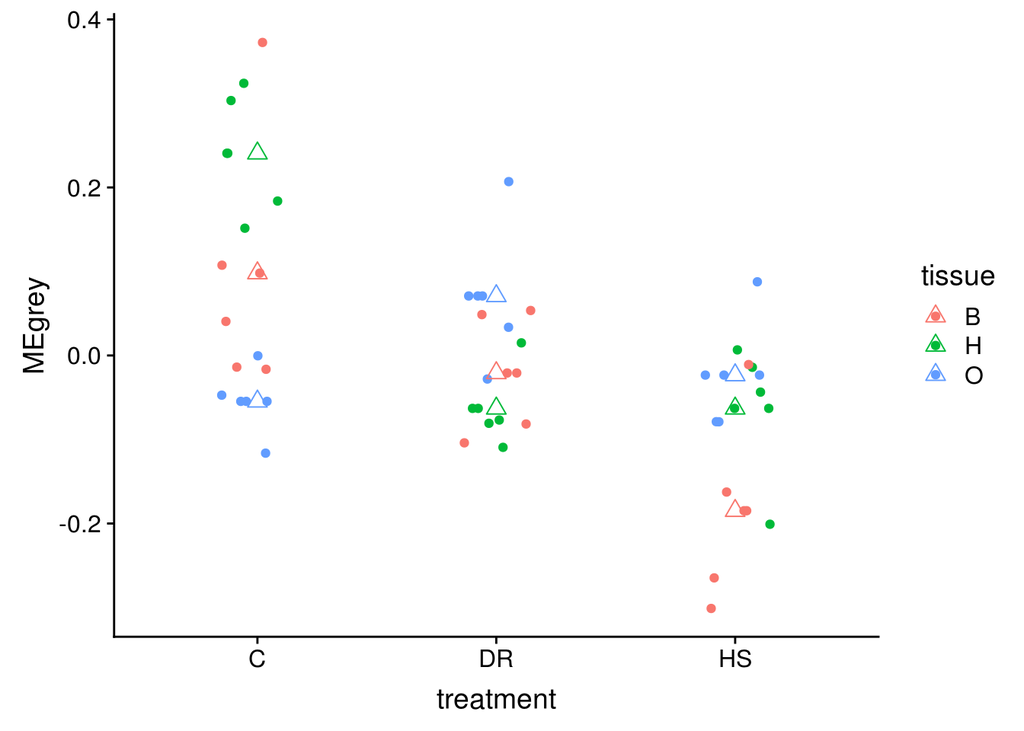

```r
all.plots[[10]]
```

```r
aov.mod_grey <- aov(eg.genes[,"MEgrey"] ~ phenDat.sva$treatment* phenDat.sva$tissue)
summary(aov.mod_grey)
```

```
##                                          Df Sum Sq Mean Sq F value   Pr(>F)
## phenDat.sva$treatment                     2 0.3088 0.15438  24.086 7.73e-08 ***
## phenDat.sva$tissue                        2 0.0496 0.02479   3.867   0.0282 *
## phenDat.sva$treatment:phenDat.sva$tissue  4 0.3532 0.08831  13.777 2.06e-07 ***
## Residuals                                45 0.2884 0.00641
## ---
## Signif. codes:  0 '***' 0.001 '**' 0.01 '*' 0.05 '.' 0.1 ' ' 1
```

```r
subset(screenTab,screenTab$module=="grey")
```

```
##     module size  p-val Bonf nInTerm ont                                term name
## 91    grey   45 0.0017    1       1  MF N6-(1,2-dicarboxyethyl)AMP AMP-lyase (fu
## 92    grey   45 0.0017    1       1  MF (S)-2-(5-amino-1-(5-phospho-D-ribosyl)im
## 93    grey   45 0.0035    1       1  BP       'de novo' AMP biosynthetic process
## 94    grey   45 0.0035    1       1  MF phosphatidylinositol 3-kinase catalytic
## 95    grey   45 0.0052    1       1  BP positive regulation of autophagosome mat
## 96    grey   45 0.0052    1       1  BP regulation of mitochondrial transcriptio
## 97    grey   45 0.0052    1       1  MF        aminoacyl-tRNA hydrolase activity
## 98    grey   45 0.0070    1       1  BP             tRNA pseudouridine synthesis
## 99    grey   45 0.0070    1       1  BP          mitochondrial ribosome assembly
## 100   grey   45 0.0070    1       1  BP   regulation of autophagosome maturation
```

45 genes Tissue* treatment*** interaction*** B&H high in C, high intermediate in DR & low in HS; O low in C high in DR & lower in HS See p-values!!

## Lightcyan module

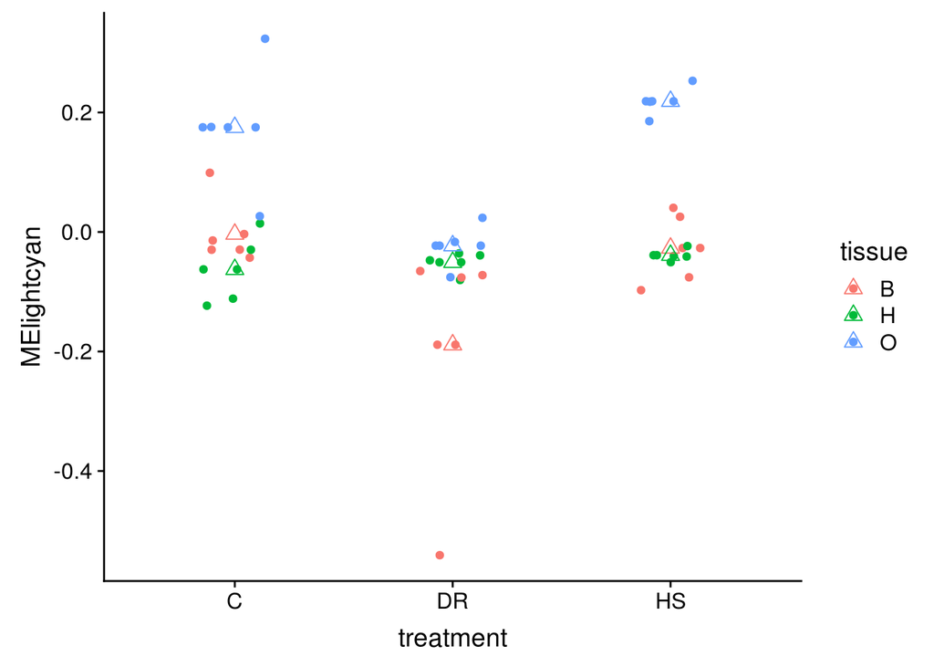

```r
all.plots[[11]]
```

```r
aov.mod_lightcyan <- aov(eg.genes[,"MElightcyan"] ~ phenDat.sva$treatment* phenDat.sva$tissue)
summary(aov.mod_lightcyan)
```

```
##                                          Df Sum Sq Mean Sq F value   Pr(>F)
## phenDat.sva$treatment                     2 0.2082 0.10410  18.040 1.77e-06 ***
## phenDat.sva$tissue                        2 0.4176 0.20878  36.178 4.30e-10 ***
## phenDat.sva$treatment:phenDat.sva$tissue  4 0.1146 0.02864   4.963  0.00212 **
## Residuals                                45 0.2597 0.00577
## ---
## Signif. codes:  0 '***' 0.001 '**' 0.01 '*' 0.05 '.' 0.1 ' ' 1
```

```r
lightcyan_ph <- TukeyHSD(aov.mod_lightcyan)
lightcyan_ph
```

```
##   Tukey multiple comparisons of means
##     95% family-wise confidence level
##
## Fit: aov(formula = eg.genes[, "MElightcyan"] ~ phenDat.sva$treatment * phenDat.sva$tissue)
##
## $`phenDat.sva$treatment`
##             diff         lwr         upr     p adj
## DR-C  -0.1237754 -0.18514583 -0.06240505 0.0000392
## HS-C   0.0146645 -0.04670589  0.07603489 0.8319212
## HS-DR  0.1384399  0.07706954  0.19981033 0.0000057
##
## $`phenDat.sva$tissue`
##           diff        lwr        upr     p adj
## H-B 0.02229949 -0.0390709 0.08366988 0.6551685
## O-B 0.19668409  0.1353137 0.25805448 0.0000000
## O-H 0.17438459  0.1130142 0.23575498 0.0000000
##
## $`phenDat.sva$treatment:phenDat.sva$tissue`
##                   diff          lwr         upr     p adj
## DR:B-C:B  -0.185171082 -0.328024931 -0.04231723 0.0034011
## HS:B-C:B  -0.023338467 -0.166192315  0.11951538 0.9998047
## C:H-C:B   -0.059068925 -0.201922773  0.08378492 0.9111634
## DR:H-C:B  -0.047189025 -0.190042873  0.09566482 0.9748408
## HS:H-C:B  -0.035353124 -0.178206973  0.10750072 0.9961212
## C:O-C:B    0.178653896  0.035800048  0.32150774 0.0053051
## DR:O-C:B  -0.019381239 -0.162235087  0.12347261 0.9999520
## HS:O-C:B   0.222270050  0.079416202  0.36512390 0.0002356
## HS:B-DR:B  0.161832615  0.018978767  0.30468646 0.0159526
## C:H-DR:B   0.126102157 -0.016751691  0.26895601 0.1224451
## DR:H-DR:B  0.137982057 -0.004871791  0.28083591 0.0656673
## HS:H-DR:B  0.149817958  0.006964109  0.29267181 0.0333447
## C:O-DR:B   0.363824978  0.220971130  0.50667883 0.0000000
## DR:O-DR:B  0.165789843  0.022935995  0.30864369 0.0123947
## HS:O-DR:B  0.407441132  0.264587284  0.55029498 0.0000000
## C:H-HS:B  -0.035730458 -0.178584306  0.10712339 0.9958295
## DR:H-HS:B -0.023850558 -0.166704406  0.11900329 0.9997703
## HS:H-HS:B -0.012014658 -0.154868506  0.13083919 0.9999988
## C:O-HS:B   0.201992363  0.059138514  0.34484621 0.0010399
## DR:O-HS:B  0.003957228 -0.138896620  0.14681108 1.0000000
## HS:O-HS:B  0.245608517  0.102754669  0.38846237 0.0000405
## DR:H-C:H   0.011879900 -0.130973949  0.15473375 0.9999989
## HS:H-C:H   0.023715800 -0.119138048  0.16656965 0.9997798
## C:O-C:H    0.237722821  0.094868972  0.38057667 0.0000738
## DR:O-C:H   0.039687686 -0.103166163  0.18254153 0.9915735
## HS:O-C:H   0.281338975  0.138485127  0.42419282 0.0000026
## HS:H-DR:H  0.011835900 -0.131017948  0.15468975 0.9999990
## C:O-DR:H   0.225842921  0.082989072  0.36869677 0.0001804
## DR:O-DR:H  0.027807786 -0.115046063  0.17066163 0.9992890
## HS:O-DR:H  0.269459075  0.126605227  0.41231292 0.0000065
## C:O-HS:H   0.214007021  0.071153172  0.35686087 0.0004341
## DR:O-HS:H  0.015971886 -0.126881963  0.15882573 0.9999892
## HS:O-HS:H  0.257623175  0.114769326  0.40047702 0.0000161
## DR:O-C:O  -0.198035135 -0.340888983 -0.05518129 0.0013802
## HS:O-C:O   0.043616154 -0.099237694  0.18647000 0.9845293
## HS:O-DR:O  0.241651289  0.098797441  0.38450514 0.0000547
```

```r
subset(screenTab,screenTab$module=="lightcyan")
```

```
##        module size   p-val    Bonf nInTerm ont                                term name
## 101 lightcyan  117 5.8e-13 4.9e-09      63  BP          cellular component organization
## 102 lightcyan  117 3.4e-11 2.8e-07      50  BP          regulation of metabolic process
## 103 lightcyan  117 1.4e-10 1.2e-06      54  BP       multicellular organism development
## 104 lightcyan  117 4.3e-10 3.6e-06      45  BP                   organelle organization
## 105 lightcyan  117 9.3e-10 7.8e-06      20  BP                   chromatin organization
## 106 lightcyan  117 1.1e-09 8.9e-06      25  BP                  chromosome organization
## 107 lightcyan  117 1.9e-09 1.6e-05      56  BP         anatomical structure development
## 108 lightcyan  117 2.6e-09 2.2e-05      44  BP regulation of cellular metabolic process
## 109 lightcyan  117 5.4e-09 4.5e-05      38  BP                         cell development
## 110 lightcyan  117 1.0e-08 8.4e-05      56  BP                    developmental process
```

117 genes Tissue*** treatment*** interaction** Treatment highly sig for DR-C and HS-DR, insig for HS-C Tissue insig for H-B, highly sig for O-B and O-H (O high in C and HS, low in DR)

## Lightgreen module

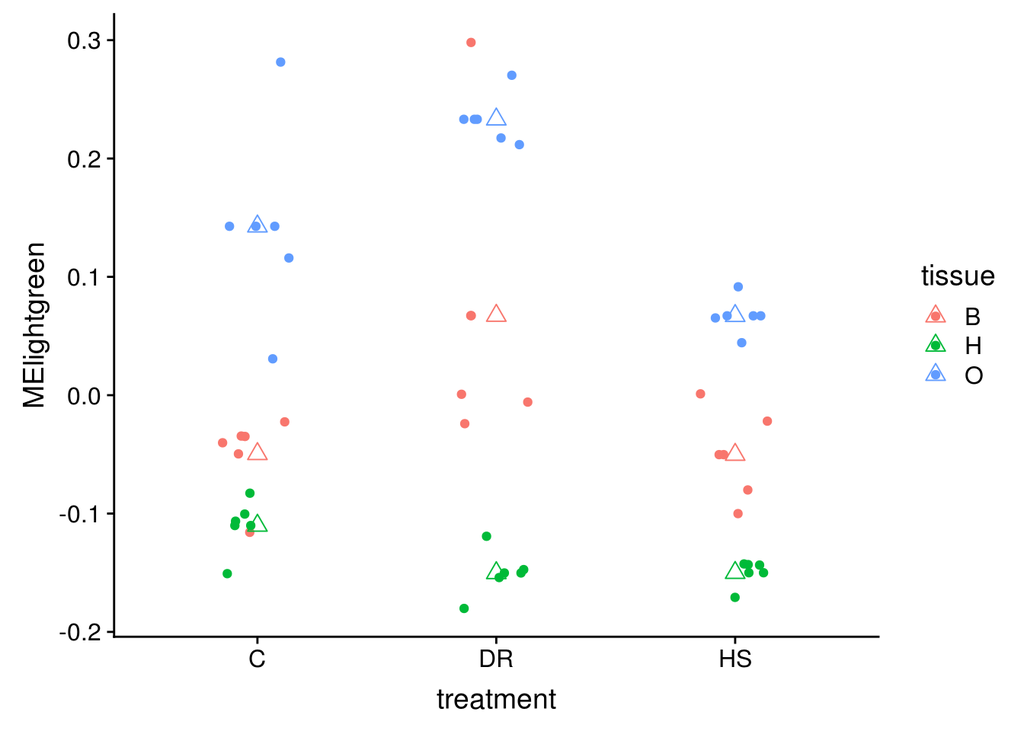

```r
all.plots[[12]]
```

```r
aov.mod_lightgreen <- aov(eg.genes[,"MElightgreen"] ~ phenDat.sva$treatment* phenDat.sva$tissue)
summary(aov.mod_lightgreen)
```

```
##                                          Df Sum Sq Mean Sq F value   Pr(>F)
## phenDat.sva$treatment                     2 0.0811  0.0406   14.66 1.25e-05 ***
## phenDat.sva$tissue                        2 0.7313  0.3656  132.13  < 2e-16 ***
## phenDat.sva$treatment:phenDat.sva$tissue  4 0.0631  0.0158    5.70 0.000846 ***
## Residuals                                45 0.1245  0.0028
## ---
## Signif. codes:  0 '***' 0.001 '**' 0.01 '*' 0.05 '.' 0.1 ' ' 1
```

```r
lightgreen_ph <- TukeyHSD(aov.mod_lightgreen)
lightgreen_ph
```

```
##   Tukey multiple comparisons of means
##     95% family-wise confidence level
##
## Fit: aov(formula = eg.genes[, "MElightgreen"] ~ phenDat.sva$treatment * phenDat.sva$tissue)
##
## $`phenDat.sva$treatment`
##              diff         lwr          upr     p adj
## DR-C   0.05571512  0.01321810  0.098212128 0.0074268
## HS-C  -0.03872361 -0.08122062  0.003773403 0.0806018
## HS-DR -0.09443873 -0.13693574 -0.051941713 0.0000074
##
## $`phenDat.sva$tissue`
##           diff        lwr         upr p adj
## H-B -0.1259242 -0.1684212 -0.08342719     0
## O-B  0.1585000  0.1160029  0.20099697     0
## O-H  0.2844242  0.2419271  0.32692117     0
##
## $`phenDat.sva$treatment:phenDat.sva$tissue`
##                    diff          lwr           upr     p adj
## DR:B-C:B   0.1168260582  0.017904385  0.2157477315 0.0102606
## HS:B-C:B  -0.0006322931 -0.099553966  0.0982893802 1.0000000
## C:H-C:B   -0.0605321730 -0.159453846  0.0383895003 0.5559113
## DR:H-C:B  -0.1006181297 -0.199539803 -0.0016964564 0.0434458
## HS:H-C:B  -0.1004285266 -0.199350200 -0.0015068533 0.0441383
## C:O-C:B    0.1923101898  0.093388517  0.2912318631 0.0000034
## DR:O-C:B   0.2827154374  0.183793764  0.3816371107 0.0000000
## HS:O-C:B   0.1166680098  0.017746336  0.2155896831 0.0104141
## HS:B-DR:B -0.1174583513 -0.216380025 -0.0185366780 0.0096674
## C:H-DR:B  -0.1773582312 -0.276279905 -0.0784365579 0.0000181
## DR:H-DR:B -0.2174441879 -0.316365861 -0.1185225146 0.0000002
## HS:H-DR:B -0.2172545847 -0.316176258 -0.1183329114 0.0000002
## C:O-DR:B   0.0754841317 -0.023437542  0.1744058050 0.2662094
## DR:O-DR:B  0.1658893793  0.066967706  0.2648110526 0.0000642
## HS:O-DR:B -0.0001580484 -0.099079722  0.0987636249 1.0000000
## C:H-HS:B  -0.0598998799 -0.158821553  0.0390217934 0.5696388
## DR:H-HS:B -0.0999858366 -0.198907510 -0.0010641633 0.0457936
## HS:H-HS:B -0.0997962335 -0.198717907 -0.0008745602 0.0465193
## C:O-HS:B   0.1929424829  0.094020810  0.2918641562 0.0000032
## DR:O-HS:B  0.2833477305  0.184426057  0.3822694038 0.0000000
## HS:O-HS:B  0.1173003029  0.018378630  0.2162219762 0.0098126
## DR:H-C:H  -0.0400859567 -0.139007630  0.0588357166 0.9200006
## HS:H-C:H  -0.0398963535 -0.138818027  0.0590253198 0.9219664
## C:O-C:H    0.2528423629  0.153920690  0.3517640362 0.0000000
## DR:O-C:H   0.3432476105  0.244325937  0.4421692838 0.0000000
## HS:O-C:H   0.1772001828  0.078278510  0.2761218561 0.0000184
## HS:H-DR:H  0.0001896031 -0.098732070  0.0991112764 1.0000000
## C:O-DR:H   0.2929283196  0.194006646  0.3918499929 0.0000000
## DR:O-DR:H  0.3833335672  0.284411894  0.4822552405 0.0000000
## HS:O-DR:H  0.2172861395  0.118364466  0.3162078128 0.0000002
## C:O-HS:H   0.2927387164  0.193817043  0.3916603897 0.0000000
## DR:O-HS:H  0.3831439640  0.284222291  0.4820656373 0.0000000
## HS:O-HS:H  0.2170965364  0.118174863  0.3160182097 0.0000002
## DR:O-C:O   0.0904052476 -0.008516426  0.1893269209 0.0976525
## HS:O-C:O  -0.0756421801 -0.174563853  0.0232794932 0.2637388
## HS:O-DR:O -0.1660474277 -0.264969101 -0.0671257544 0.0000631
```

```r
subset(screenTab,screenTab$module=="lightgreen")
```

```
##         module size   p-val    Bonf nInTerm ont                             term name
## 111 lightgreen  107 2.1e-30 1.7e-26      24  CC                mitochondrial ribosome
## 112 lightgreen  107 7.0e-29 5.9e-25      25  BP             mitochondrial translation
## 113 lightgreen  107 9.5e-27 8.0e-23      27  CC                  mitochondrial matrix
## 114 lightgreen  107 2.1e-22 1.7e-18      25  CC                              ribosome
## 115 lightgreen  107 7.0e-21 5.8e-17      23  MF    structural constituent of ribosome
## 116 lightgreen  107 1.0e-19 8.5e-16      37  CC                         mitochondrion
## 117 lightgreen  107 2.5e-19 2.1e-15      15  CC mitochondrial large ribosomal subunit
## 118 lightgreen  107 2.3e-17 1.9e-13      28  BP                           translation
## 119 lightgreen  107 4.0e-17 3.3e-13      31  BP             peptide metabolic process
## 120 lightgreen  107 3.6e-14 3.0e-10      15  CC               large ribosomal subunit
```

107 genes Tissue*** treatment*** interaction*** Treatment highly sig DR-C and HS-DR, insig in HS-C Tissue highly sig in all comparisons Interaction sig in 26 diet-tissue comparisons (B&O low in C, high in DR, low in HS; H higher in C) GO: peptide metabolism, mitochondrial translation

## Lightyellow module

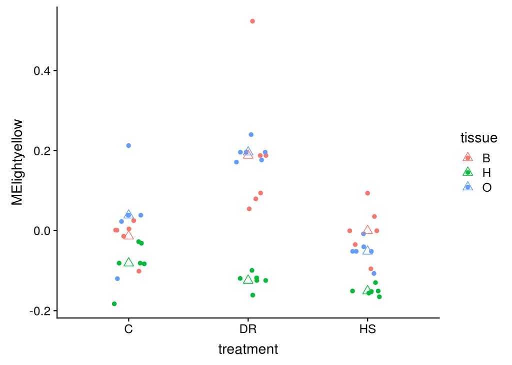

```r
all.plots[[13]]
```

```r
aov.mod_lightyellow <- aov(eg.genes[,"MElightyellow"] ~ phenDat.sva$treatment* phenDat.sva$tissue)
summary(aov.mod_lightyellow)
```

```
##                                          Df Sum Sq Mean Sq F value   Pr(>F)
## phenDat.sva$treatment                     2 0.2230 0.11152  19.066 1.01e-06 ***
## phenDat.sva$tissue                        2 0.3811 0.19054  32.577 1.79e-09 ***
## phenDat.sva$treatment:phenDat.sva$tissue  4 0.1327 0.03317   5.671 0.000877 ***
## Residuals                                45 0.2632 0.00585
## ---
## Signif. codes:  0 '***' 0.001 '**' 0.01 '*' 0.05 '.' 0.1 ' ' 1
```

```r
lightyellow_ph <- TukeyHSD(aov.mod_lightyellow)
lightyellow_ph
```

```
##   Tukey multiple comparisons of means
##     95% family-wise confidence level
##
## Fit: aov(formula = eg.genes[, "MElightyellow"] ~ phenDat.sva$treatment * phenDat.sva$tissue)
##
## $`phenDat.sva$treatment`
##             diff         lwr         upr     p adj
## DR-C   0.1052366  0.04345169  0.16702147 0.0004514
## HS-C  -0.0487746 -0.11055949  0.01301029 0.1466606
## HS-DR -0.1540112 -0.21579607 -0.09222629 0.0000008
##
## $`phenDat.sva$tissue`
##             diff         lwr         upr     p adj
## H-B -0.176644969 -0.23842986 -0.11486008 0.0000000
## O-B  0.003081192 -0.05870369  0.06486608 0.9919801
## O-H  0.179726161  0.11794127  0.24151105 0.0000000
##
## $`phenDat.sva$treatment:phenDat.sva$tissue`
##                  diff         lwr          upr     p adj
## DR:B-C:B   0.20160330  0.05778462  0.345421990 0.0011782
## HS:B-C:B   0.01356208 -0.13025661  0.157380766 0.9999971
## C:H-C:B   -0.06728961 -0.21110829  0.076529080 0.8383543
## DR:H-C:B  -0.11057235 -0.25439104  0.033246333 0.2573702
## HS:H-C:B  -0.13690756 -0.28072625  0.006911122 0.0732130
## C:O-C:B    0.05242924 -0.09138945  0.196247922 0.9551279
## DR:O-C:B   0.20981841  0.06599973  0.353637100 0.0006537
## HS:O-C:B  -0.03783869 -0.18165738  0.105979997 0.9941283
## HS:B-DR:B -0.18804122 -0.33185991 -0.044222537 0.0030435
## C:H-DR:B  -0.26889291 -0.41271160 -0.125074223 0.0000078
## DR:H-DR:B -0.31217566 -0.45599434 -0.168356970 0.0000003
## HS:H-DR:B -0.33851087 -0.48232955 -0.194692182 0.0000000
## C:O-DR:B  -0.14917407 -0.29299275 -0.005355382 0.0367501
## DR:O-DR:B  0.00821511 -0.13560358  0.152033796 0.9999999
## HS:O-DR:B -0.23944199 -0.38326068 -0.095623307 0.0000731
## C:H-HS:B  -0.08085169 -0.22467037  0.062967000 0.6620119
## DR:H-HS:B -0.12413443 -0.26795312  0.019684253 0.1404955
## HS:H-HS:B -0.15046964 -0.29428833 -0.006650958 0.0340602
## C:O-HS:B   0.03886716 -0.10495153  0.182685842 0.9929783
## DR:O-HS:B  0.19625633  0.05243765  0.340075020 0.0017193
## HS:O-HS:B -0.05140077 -0.19521946  0.092417917 0.9599377
## DR:H-C:H  -0.04328275 -0.18710143  0.100535939 0.9858760
## HS:H-C:H  -0.06961796 -0.21343664  0.074200728 0.8120052
## C:O-C:H    0.11971884 -0.02409984  0.263537528 0.1729083
## DR:O-C:H   0.27710802  0.13328933  0.420926706 0.0000041
## HS:O-C:H   0.02945092 -0.11436777  0.173269603 0.9989745
## HS:H-DR:H -0.02633521 -0.17015390  0.117483475 0.9995451
## C:O-DR:H   0.16300159  0.01918290  0.306820275 0.0158767
## DR:O-DR:H  0.32039077  0.17657208  0.464209453 0.0000001
## HS:O-DR:H  0.07273366 -0.07108502  0.216552350 0.7737976
## C:O-HS:H   0.18933680  0.04551811  0.333155486 0.0027837
## DR:O-HS:H  0.34672598  0.20290729  0.490544664 0.0000000
## HS:O-HS:H  0.09906888 -0.04474981  0.242887561 0.3966522
## DR:O-C:O   0.15738918  0.01357049  0.301207864 0.0224824
## HS:O-C:O  -0.09026792 -0.23408661  0.053550761 0.5222525
## HS:O-DR:O -0.24765710 -0.39147579 -0.103838417 0.0000393
```

```r
subset(screenTab,screenTab$module=="lightyellow")
```

```
##          module size   p-val    Bonf nInTerm ont                              term name
## 121 lightyellow  107 1.1e-11 8.9e-08      67  CC                              cytoplasm
## 122 lightyellow  107 1.6e-09 1.3e-05       9  CC               Golgi-associated vesicle
## 123 lightyellow  107 1.6e-09 1.4e-05      25  CC                          mitochondrion
## 124 lightyellow  107 5.6e-09 4.7e-05       7  CC      Golgi-associated vesicle membrane
## 125 lightyellow  107 6.6e-09 5.6e-05       9  CC                         coated vesicle
## 126 lightyellow  107 8.5e-09 7.1e-05       5  CC                      COPI vesicle coat
## 127 lightyellow  107 8.5e-09 7.1e-05       5  CC                    COPI-coated vesicle
## 128 lightyellow  107 2.5e-07 2.1e-03       8  BP ER to Golgi vesicle-mediated transport
## 129 lightyellow  107 5.5e-07 4.6e-03      10  BP                Golgi vesicle transport
## 130 lightyellow  107 7.4e-07 6.2e-03      76  CC                          intracellular
```

107 genes Tissue*** treatment*** interaction*** Treatment highly sig for DR-C and HS-DR, insig for HS-C Tissue highly sig for H-B and O-H, insig for O-B Interaction sig for 17 diet-tissue contrasts (B&O low in C, high in DR, low in HS; H higher in C) (trend too similar to Lightgreen) GO: Golgi vesicle transport

## Pink module

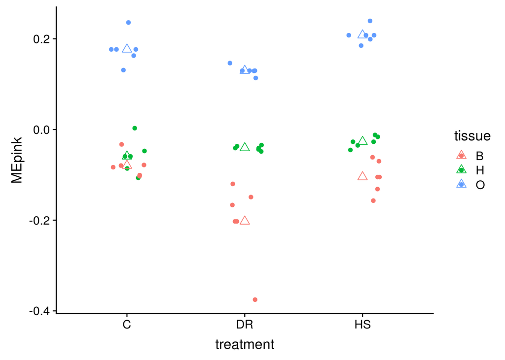

```r
all.plots[[14]]
```

```r
aov.mod_pink <- aov(eg.genes[,"MEpink"] ~ phenDat.sva$treatment* phenDat.sva$tissue)
summary(aov.mod_pink)
```

```
##                                          Df Sum Sq Mean Sq F value   Pr(>F)
## phenDat.sva$treatment                     2 0.0403  0.0202  13.688 2.27e-05 ***
## phenDat.sva$tissue                        2 0.8613  0.4306 292.315  < 2e-16 ***
## phenDat.sva$treatment:phenDat.sva$tissue  4 0.0321  0.0080   5.452  0.00115 **
## Residuals                                45 0.0663  0.0015
## ---
## Signif. codes:  0 '***' 0.001 '**' 0.01 '*' 0.05 '.' 0.1 ' ' 1
```

```r
pink_ph <- TukeyHSD(aov.mod_pink)
pink_ph
```

```
##   Tukey multiple comparisons of means
##     95% family-wise confidence level
##
## Fit: aov(formula = eg.genes[, "MEpink"] ~ phenDat.sva$treatment * phenDat.sva$tissue)
##
## $`phenDat.sva$treatment`
##              diff         lwr         upr     p adj
## DR-C  -0.05056682 -0.08157433 -0.01955931 0.0007769
## HS-C   0.01270454 -0.01830297  0.04371205 0.5850399
## HS-DR  0.06327136  0.03226385  0.09427887 0.0000324
##
## $`phenDat.sva$tissue`
##           diff        lwr       upr p adj
## H-B 0.08663113 0.05562362 0.1176386 1e-07
## O-B 0.30049731 0.26948980 0.3315048 0e+00
## O-H 0.21386618 0.18285867 0.2448737 0e+00
##
## $`phenDat.sva$treatment:phenDat.sva$tissue`
##                  diff          lwr         upr     p adj
## DR:B-C:B  -0.12315186 -0.195329041 -0.05097467 0.0000467
## HS:B-C:B  -0.02531741 -0.097494600  0.04685977 0.9640599
## C:H-C:B    0.02029150 -0.051885683  0.09246869 0.9908927
## DR:H-C:B   0.03865055 -0.033526638  0.11082773 0.7166567
## HS:H-C:B   0.05248207 -0.019695115  0.12465925 0.3256879
## C:O-C:B    0.25622995  0.184052761  0.32840713 0.0000000
## DR:O-C:B   0.20932230  0.137145115  0.28149948 0.0000000
## HS:O-C:B   0.28747041  0.215293225  0.35964759 0.0000000
## HS:B-DR:B  0.09783444  0.025657256  0.17001163 0.0018853
## C:H-DR:B   0.14344336  0.071266173  0.21562054 0.0000021
## DR:H-DR:B  0.16180240  0.089625218  0.23397959 0.0000001
## HS:H-DR:B  0.17563393  0.103456741  0.24781111 0.0000000
## C:O-DR:B   0.37938180  0.307204617  0.45155899 0.0000000
## DR:O-DR:B  0.33247416  0.260296971  0.40465134 0.0000000
## HS:O-DR:B  0.41062227  0.338445081  0.48279945 0.0000000
## C:H-HS:B   0.04560892 -0.026568268  0.11778610 0.5132091
## DR:H-HS:B  0.06396796 -0.008209223  0.13614515 0.1194051
## HS:H-HS:B  0.07779948  0.005622300  0.14997667 0.0259613
## C:O-HS:B   0.28154736  0.209370176  0.35372455 0.0000000
## DR:O-HS:B  0.23463971  0.162462530  0.30681690 0.0000000
## HS:O-HS:B  0.31278782  0.240610640  0.38496501 0.0000000
## DR:H-C:H   0.01835904 -0.053818140  0.09053623 0.9953243
## HS:H-C:H   0.03219057 -0.039986617  0.10436775 0.8706650
## C:O-C:H    0.23593844  0.163761259  0.30811563 0.0000000
## DR:O-C:H   0.18903080  0.116853613  0.26120798 0.0000000
## HS:O-C:H   0.26717891  0.195001723  0.33935609 0.0000000
## HS:H-DR:H  0.01383152 -0.058345662  0.08600871 0.9993656
## C:O-DR:H   0.21757940  0.145402215  0.28975658 0.0000000
## DR:O-DR:H  0.17067175  0.098494568  0.24284894 0.0000000
## HS:O-DR:H  0.24881986  0.176642678  0.32099705 0.0000000
## C:O-HS:H   0.20374788  0.131570692  0.27592506 0.0000000
## DR:O-HS:H  0.15684023  0.084663045  0.22901741 0.0000003
## HS:O-HS:H  0.23498834  0.162811155  0.30716552 0.0000000
## DR:O-C:O  -0.04690765 -0.119084831  0.02526954 0.4753266
## HS:O-C:O   0.03124046 -0.040936721  0.10341765 0.8881662
## HS:O-DR:O  0.07814811  0.005970925  0.15032529 0.0248928
```

```r
subset(screenTab,screenTab$module=="pink")
```

```
##     module size   p-val    Bonf nInTerm ont                                term name
## 131   pink  382 9.1e-16 7.6e-12     144  CC                                  nucleus
## 132   pink  382 4.0e-15 3.4e-11     125  BP          regulation of metabolic process
## 133   pink  382 5.3e-15 4.5e-11     102  BP            regulation of gene expression
## 134   pink  382 8.3e-15 7.0e-11      89  BP      regulation of RNA metabolic process
## 135   pink  382 7.1e-14 5.9e-10     114  BP regulation of cellular metabolic process
## 136   pink  382 3.2e-13 2.6e-09     251  CC                            intracellular
## 137   pink  382 4.9e-13 4.1e-09      81  BP regulation of transcription, DNA-templat
## 138   pink  382 4.7e-12 4.0e-08      81  BP             transcription, DNA-templated
## 139   pink  382 7.3e-12 6.2e-08      52  CC                               chromosome
## 140   pink  382 1.9e-11 1.6e-07     125  BP                          gene expression
```

## Red module

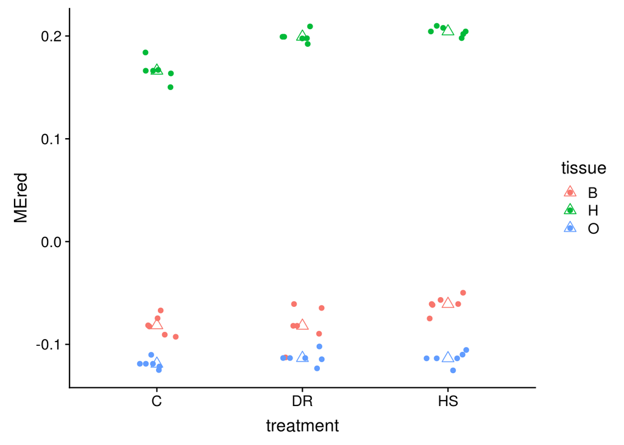

```r
all.plots[[15]]
```

```r
aov.mod_red <- aov(eg.genes[,"MEred"] ~ phenDat.sva$treatment* phenDat.sva$tissue)
summary(aov.mod_red)
```

```
##                                          Df Sum Sq Mean Sq  F value   Pr(>F)
## phenDat.sva$treatment                     2 0.0042  0.0021   23.826 8.77e-08 ***
## phenDat.sva$tissue                        2 0.9890  0.4945 5641.954  < 2e-16 ***
## phenDat.sva$treatment:phenDat.sva$tissue  4 0.0029  0.0007    8.152 4.94e-05 ***
## Residuals                                45 0.0039  0.0001
## ---
## Signif. codes:  0 '***' 0.001 '**' 0.01 '*' 0.05 '.' 0.1 ' ' 1
```

```r
red_ph <- TukeyHSD(aov.mod_red)
red_ph
```

```
##   Tukey multiple comparisons of means
##     95% family-wise confidence level
##
## Fit: aov(formula = eg.genes[, "MEred"] ~ phenDat.sva$treatment * phenDat.sva$tissue)
##
## $`phenDat.sva$treatment`
##              diff         lwr        upr     p adj
## DR-C  0.012731038 0.005167671 0.02029440 0.0005249
## HS-C  0.021415216 0.013851849 0.02897858 0.0000000
## HS-DR 0.008684178 0.001120811 0.01624754 0.0210218
##
## $`phenDat.sva$tissue`
##           diff         lwr         upr p adj
## H-B  0.2646703  0.25710698  0.27223371     0
## O-B -0.0405250 -0.04808837 -0.03296164     0
## O-H -0.3051953 -0.31275871 -0.29763198     0
##
## $`phenDat.sva$treatment:phenDat.sva$tissue`
##                    diff          lwr         upr     p adj
## DR:B-C:B  -0.0004422307 -0.018047725  0.01716326 1.0000000
## HS:B-C:B   0.0207413057  0.003135811  0.03834680 0.0105389
## C:H-C:B    0.2476839805  0.230078486  0.26528947 0.0000000
## DR:H-C:B   0.2807321298  0.263126636  0.29833762 0.0000000
## HS:H-C:B   0.2858939937  0.268288499  0.30349949 0.0000000
## C:O-C:B   -0.0373858200 -0.054991314 -0.01978033 0.0000005
## DR:O-C:B  -0.0317986259 -0.049404120 -0.01419313 0.0000156
## HS:O-C:B  -0.0320914923 -0.049696987 -0.01448600 0.0000130
## HS:B-DR:B  0.0211835364  0.003578042  0.03878903 0.0083328
## C:H-DR:B   0.2481262112  0.230520717  0.26573171 0.0000000
## DR:H-DR:B  0.2811743605  0.263568866  0.29877985 0.0000000
## HS:H-DR:B  0.2863362244  0.268730730  0.30394172 0.0000000
## C:O-DR:B  -0.0369435893 -0.054549084 -0.01933810 0.0000006
## DR:O-DR:B -0.0313563953 -0.048961890 -0.01375090 0.0000206
## HS:O-DR:B -0.0316492616 -0.049254756 -0.01404377 0.0000172
## C:H-HS:B   0.2269426748  0.209337181  0.24454817 0.0000000
## DR:H-HS:B  0.2599908241  0.242385330  0.27759632 0.0000000
## HS:H-HS:B  0.2651526880  0.247547194  0.28275818 0.0000000
## C:O-HS:B  -0.0581271257 -0.075732620 -0.04052163 0.0000000
## DR:O-HS:B -0.0525399316 -0.070145426 -0.03493444 0.0000000
## HS:O-HS:B -0.0528327979 -0.070438292 -0.03522730 0.0000000
## DR:H-C:H   0.0330481493  0.015442655  0.05065364 0.0000072
## HS:H-C:H   0.0382100132  0.020604519  0.05581551 0.0000003
## C:O-C:H   -0.2850698004 -0.302675295 -0.26746431 0.0000000
## DR:O-C:H  -0.2794826064 -0.297088101 -0.26187711 0.0000000
## HS:O-C:H  -0.2797754727 -0.297380967 -0.26216998 0.0000000
## HS:H-DR:H  0.0051618639 -0.012443630  0.02276736 0.9880442
## C:O-DR:H  -0.3181179497 -0.335723444 -0.30051246 0.0000000
## DR:O-DR:H -0.3125307557 -0.330136250 -0.29492526 0.0000000
## HS:O-DR:H -0.3128236220 -0.330429116 -0.29521813 0.0000000
## C:O-HS:H  -0.3232798137 -0.340885308 -0.30567432 0.0000000
## DR:O-HS:H -0.3176926196 -0.335298114 -0.30008713 0.0000000
## HS:O-HS:H -0.3179854860 -0.335590980 -0.30037999 0.0000000
## DR:O-C:O   0.0055871940 -0.012018300  0.02319269 0.9803079
## HS:O-C:O   0.0052943277 -0.012311167  0.02289982 0.9859454
## HS:O-DR:O -0.0002928663 -0.017898361  0.01731263 1.0000000
```

```r
subset(screenTab,screenTab$module=="red")
```

```
##     module size   p-val    Bonf nInTerm ont                                term name
## 141    red  787 6.1e-32 5.1e-28     109  BP                   nervous system process
## 142    red  787 9.9e-31 8.3e-27      47  BP detection of stimulus involved in sensor
## 143    red  787 1.2e-30 1.0e-26      62  BP  sensory perception of chemical stimulus
## 144    red  787 2.0e-30 1.7e-26      40  BP detection of chemical stimulus involved
## 145    red  787 3.2e-29 2.7e-25     104  CC                          cell projection
## 146    red  787 6.0e-29 5.0e-25      44  BP           detection of chemical stimulus
## 147    red  787 4.1e-27 3.4e-23      31  MF              olfactory receptor activity
## 148    red  787 3.1e-26 2.6e-22      43  BP              sensory perception of smell
## 149    red  787 7.0e-26 5.9e-22      31  BP detection of chemical stimulus involved
## 150    red  787 3.8e-23 3.2e-19      35  MF                          odorant binding
```

787 genes Tissue*** treatment*** interaction*** Treatment highly sig for HS-C and DR-C, mildly for HS-DR Tissue highly sig for all 3 comparisons (subtlely increasing in all tissue across C, DR, HS) GO: olfactory and sensory perception of smell or chemical stimulus

## Royalblue

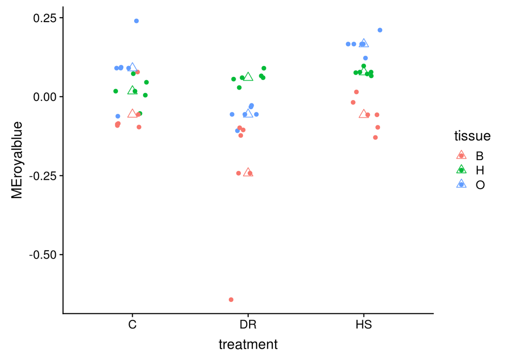

```r
all.plots[[16]]
```

```r
aov.mod_royalblue <- aov(eg.genes[,"MEroyalblue"] ~ phenDat.sva$treatment* phenDat.sva$tissue)
summary(aov.mod_royalblue)
```

```
##                                          Df Sum Sq Mean Sq F value   Pr(>F)
## phenDat.sva$treatment                     2 0.1887 0.09435  13.477 2.59e-05 ***
## phenDat.sva$tissue                        2 0.3823 0.19114  27.300 1.72e-08 ***
## phenDat.sva$treatment:phenDat.sva$tissue  4 0.1140 0.02849   4.069  0.00671 **
## Residuals                                45 0.3151 0.00700
## ---
## Signif. codes:  0 '***' 0.001 '**' 0.01 '*' 0.05 '.' 0.1 ' ' 1
```

```r
royalblue_ph <- TukeyHSD(aov.mod_royalblue)
royalblue_ph
```

```
##   Tukey multiple comparisons of means
##     95% family-wise confidence level
##
## Fit: aov(formula = eg.genes[, "MEroyalblue"] ~ phenDat.sva$treatment * phenDat.sva$tissue)
##
## $`phenDat.sva$treatment`
##              diff         lwr         upr     p adj
## DR-C  -0.09658576 -0.16418311 -0.02898841 0.0033297
## HS-C   0.04513621 -0.02246114  0.11273356 0.2485008
## HS-DR  0.14172197  0.07412462  0.20931932 0.0000207
##
## $`phenDat.sva$tissue`
##          diff         lwr        upr     p adj
## H-B 0.1703856  0.10278824 0.23798294 0.0000006
## O-B 0.1856059  0.11800854 0.25320324 0.0000001
## O-H 0.0152203 -0.05237705 0.08281765 0.8491838
##
## $`phenDat.sva$treatment:phenDat.sva$tissue`
##                    diff          lwr         upr     p adj
## DR:B-C:B  -0.1860001252 -0.343348670 -0.02865158 0.0101567
## HS:B-C:B  -0.0010406988 -0.158389244  0.15630785 1.0000000
## C:H-C:B    0.0737208437 -0.083627701  0.23106939 0.8373489
## DR:H-C:B   0.1163686380 -0.040979907  0.27371718 0.3042855
## HS:H-C:B   0.1340264591 -0.023322086  0.29137500 0.1518732
## C:O-C:B    0.1466793551 -0.010669190  0.30402790 0.0851601
## DR:O-C:B   0.0002744113 -0.157074134  0.15762296 1.0000000
## HS:O-C:B   0.2228230714  0.065474526  0.38017162 0.0010173
## HS:B-DR:B  0.1849594264  0.027610881  0.34230797 0.0108002
## C:H-DR:B   0.2597209688  0.102372424  0.41706951 0.0000853
## DR:H-DR:B  0.3023687631  0.145020218  0.45971731 0.0000044
## HS:H-DR:B  0.3200265843  0.162678039  0.47737513 0.0000013
## C:O-DR:B   0.3326794803  0.175330935  0.49002803 0.0000005
## DR:O-DR:B  0.1862745365  0.028925991  0.34362308 0.0099931
## HS:O-DR:B  0.4088231965  0.251474651  0.56617174 0.0000000
## C:H-HS:B   0.0747615425 -0.082587003  0.23211009 0.8267929
## DR:H-HS:B  0.1174093368 -0.039939208  0.27475788 0.2932516
## HS:H-HS:B  0.1350671579 -0.022281387  0.29241570 0.1451590
## C:O-HS:B   0.1477200539 -0.009628491  0.30506860 0.0809873
## DR:O-HS:B  0.0013151101 -0.156033435  0.15866366 1.0000000
## HS:O-HS:B  0.2238637702  0.066515225  0.38121232 0.0009505
## DR:H-C:H   0.0426477943 -0.114700751  0.19999634 0.9928411
## HS:H-C:H   0.0603056154 -0.097042930  0.21765416 0.9406607
## C:O-C:H    0.0729585115 -0.084390034  0.23030706 0.8448634
## DR:O-C:H  -0.0734464324 -0.230794978  0.08390211 0.8400753
## HS:O-C:H   0.1491022277 -0.008246317  0.30645077 0.0757153
## HS:H-DR:H  0.0176578211 -0.139690724  0.17500637 0.9999889
## C:O-DR:H   0.0303107172 -0.127037828  0.18765926 0.9993410
## DR:O-DR:H -0.1160942267 -0.273442772  0.04125432 0.3072362
## HS:O-DR:H  0.1064544334 -0.050894112  0.26380298 0.4208805
## C:O-HS:H   0.0126528960 -0.144695649  0.17000144 0.9999992
## DR:O-HS:H -0.1337520478 -0.291100593  0.02359650 0.1536834
## HS:O-HS:H  0.0887966123 -0.068551933  0.24614516 0.6575011
## DR:O-C:O  -0.1464049438 -0.303753489  0.01094360 0.0862902
## HS:O-C:O   0.0761437162 -0.081204829  0.23349226 0.8122584
## HS:O-DR:O  0.2225486601  0.065200115  0.37989721 0.0010357
```

```r
subset(screenTab,screenTab$module=="royalblue")
```

```
##        module size   p-val    Bonf nInTerm ont                                term name
## 151 royalblue  132 1.4e-12 1.1e-08      57  BP          regulation of metabolic process
## 152 royalblue  132 1.0e-11 8.5e-08      41  BP             transcription, DNA-templated
## 153 royalblue  132 2.8e-11 2.4e-07      46  BP            regulation of gene expression
## 154 royalblue  132 5.0e-11 4.2e-07      39  BP regulation of transcription, DNA-templat
## 155 royalblue  132 6.7e-11 5.6e-07      51  BP regulation of cellular metabolic process
## 156 royalblue  132 1.3e-10 1.1e-06      40  BP      regulation of RNA metabolic process
## 157 royalblue  132 1.2e-09 1.0e-05      16  CC                      polytene chromosome
## 158 royalblue  132 1.3e-09 1.1e-05      10  CC        histone methyltransferase complex
## 159 royalblue  132 2.5e-09 2.1e-05      19  BP                           cell migration
## 160 royalblue  132 1.5e-08 1.3e-04      19  BP                            cell motility
```

132 genes Tissue*** treatment*** interaction** Treatment highly sig for DR-C and HS-DR, insig for HS-C Tissue highly sig for H-B and O-B, insig for O-H (B&O high in C, low in DR, high in HS; H low, higher, high) GO: regulation of metabolic process, regulation of gene expression

## Salmon module

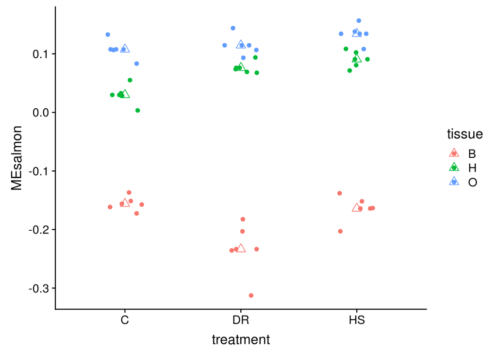

```r
all.plots[[17]]
```

```r
aov.mod_salmon <- aov(eg.genes[,"MEsalmon"] ~ phenDat.sva$treatment* phenDat.sva$tissue)
summary(aov.mod_salmon)
```

```
##                                          Df Sum Sq Mean Sq F value   Pr(>F)
## phenDat.sva$treatment                     2 0.0118  0.0059   13.69 2.27e-05 ***
## phenDat.sva$tissue                        2 0.9444  0.4722 1097.99  < 2e-16 ***
## phenDat.sva$treatment:phenDat.sva$tissue  4 0.0245  0.0061   14.23 1.39e-07 ***
## Residuals                                45 0.0194  0.0004
## ---
## Signif. codes:  0 '***' 0.001 '**' 0.01 '*' 0.05 '.' 0.1 ' ' 1
```

```r
salmon_ph <- TukeyHSD(aov.mod_salmon)
salmon_ph
```

```
##   Tukey multiple comparisons of means
##     95% family-wise confidence level
##
## Fit: aov(formula = eg.genes[, "MEsalmon"] ~ phenDat.sva$treatment * phenDat.sva$tissue)
##
## $`phenDat.sva$treatment`
##               diff          lwr        upr     p adj
## DR-C  -0.008114552 -0.024868003 0.00863890 0.4747060
## HS-C   0.026467417  0.009713966 0.04322087 0.0011314
## HS-DR  0.034581969  0.017828517 0.05133542 0.0000268
##
## $`phenDat.sva$tissue`
##           diff        lwr        upr p adj
## H-B 0.25008450 0.23333105 0.26683796     0
## O-B 0.30334772 0.28659427 0.32010117     0
## O-H 0.05326322 0.03650976 0.07001667     0
##
## $`phenDat.sva$treatment:phenDat.sva$tissue`
##                   diff           lwr         upr     p adj
## DR:B-C:B  -0.077614855 -0.1166124075 -0.03861730 0.0000021
## HS:B-C:B  -0.008178666 -0.0471762193  0.03081889 0.9987832
## C:H-C:B    0.185756111  0.1467585582  0.22475366 0.0000000
## DR:H-C:B   0.232059153  0.1930616003  0.27105671 0.0000000
## HS:H-C:B   0.246644727  0.2076471739  0.28564228 0.0000000
## C:O-C:B    0.263529726  0.2245321727  0.30252728 0.0000000
## DR:O-C:B   0.270497884  0.2315003305  0.30949544 0.0000000
## HS:O-C:B   0.290222028  0.2512244748  0.32921958 0.0000000
## HS:B-DR:B  0.069436188  0.0304386352  0.10843374 0.0000207
## C:H-DR:B   0.263370966  0.2243734127  0.30236852 0.0000000
## DR:H-DR:B  0.309674008  0.2706764548  0.34867156 0.0000000
## HS:H-DR:B  0.324259581  0.2852620284  0.36325713 0.0000000
## C:O-DR:B   0.341144580  0.3021470272  0.38014213 0.0000000
## DR:O-DR:B  0.348112738  0.3091151850  0.38711029 0.0000000
## HS:O-DR:B  0.367836882  0.3288393293  0.40683444 0.0000000
## C:H-HS:B   0.193934778  0.1549372245  0.23293233 0.0000000
## DR:H-HS:B  0.240237820  0.2012402666  0.27923537 0.0000000
## HS:H-HS:B  0.254823393  0.2158258402  0.29382095 0.0000000
## C:O-HS:B   0.271708392  0.2327108390  0.31070594 0.0000000
## DR:O-HS:B  0.278676550  0.2396789969  0.31767410 0.0000000
## HS:O-HS:B  0.298400694  0.2594031411  0.33739825 0.0000000
## DR:H-C:H   0.046303042  0.0073054891  0.08530060 0.0096724
## HS:H-C:H   0.060888616  0.0218910627  0.09988617 0.0002224
## C:O-C:H    0.077773614  0.0387760615  0.11677117 0.0000020
## DR:O-C:H   0.084741772  0.0457442194  0.12373933 0.0000003
## HS:O-C:H   0.104465917  0.0654683636  0.14346347 0.0000000
## HS:H-DR:H  0.014585574 -0.0244119794  0.05358313 0.9481603
## C:O-DR:H   0.031470572 -0.0075269806  0.07046813 0.2038238
## DR:O-DR:H  0.038438730 -0.0005588228  0.07743628 0.0561310
## HS:O-DR:H  0.058162874  0.0191653215  0.09716043 0.0004654
## C:O-HS:H   0.016884999 -0.0221125542  0.05588255 0.8879807
## DR:O-HS:H  0.023853157 -0.0151443963  0.06285071 0.5564747
## HS:O-HS:H  0.043577301  0.0045797480  0.08257485 0.0183225
## DR:O-C:O   0.006968158 -0.0320293951  0.04596571 0.9996201
## HS:O-C:O   0.026692302 -0.0123052509  0.06568986 0.4052213
## HS:O-DR:O  0.019724144 -0.0192734087  0.05872170 0.7737106
```

```r
subset(screenTab,screenTab$module=="salmon")
```

```
##     module size   p-val Bonf nInTerm ont                                term name
## 161 salmon  157 0.00034    1      24  MF                              DNA binding
## 162 salmon  157 0.00035    1      40  BP                    RNA metabolic process
## 163 salmon  157 0.00038    1       3  BP             anterograde axonal transport
## 164 salmon  157 0.00039    1      29  BP             transcription, DNA-templated
## 165 salmon  157 0.00044    1      28  BP regulation of transcription, DNA-templat
## 166 salmon  157 0.00048    1       9  BP                         synapse assembly
## 167 salmon  157 0.00053    1      34  BP            regulation of gene expression
## 168 salmon  157 0.00053    1       8  BP synaptic growth at neuromuscular junctio
## 169 salmon  157 0.00055    1       2  BP negative regulation of compound eye cone
## 170 salmon  157 0.00061    1      49  CC                                  nucleus
```

157 genes Tissue*** treatment*** interaction*** (B high, low, high; H&O low, higher, high) Treatment highly sig in HS-C and HS-DR, insig in DR-C Tissue highly sig in all 3 comparisons Interaction highly sig in 27 diet-tissue comparisons

## Skyblue module

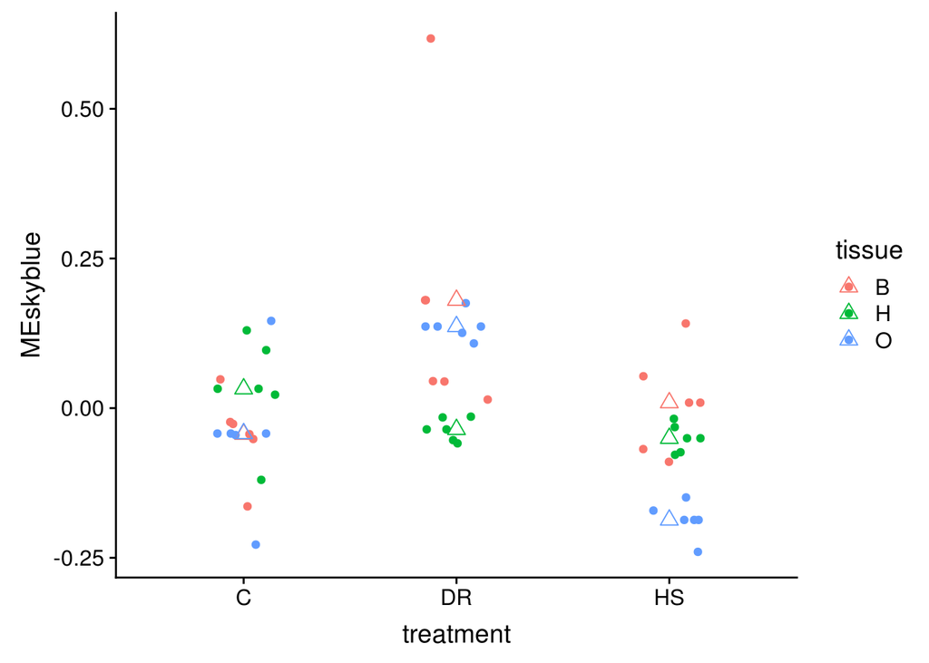

```r
all.plots[[18]]
```

```r
aov.mod_skyblue <- aov(eg.genes[,"MEskyblue"] ~ phenDat.sva$treatment* phenDat.sva$tissue)
summary(aov.mod_skyblue)
```

```
##                                          Df Sum Sq Mean Sq F value   Pr(>F)
## phenDat.sva$treatment                     2 0.2678 0.13389  13.936 1.95e-05 ***
## phenDat.sva$tissue                        2 0.0656 0.03279   3.413 0.041678 *
## phenDat.sva$treatment:phenDat.sva$tissue  4 0.2343 0.05857   6.096 0.000523 ***
## Residuals                                45 0.4324 0.00961
## ---
## Signif. codes:  0 '***' 0.001 '**' 0.01 '*' 0.05 '.' 0.1 ' ' 1
```

```r
skyblue_ph <- TukeyHSD(aov.mod_skyblue)
skyblue_ph
```

```
##   Tukey multiple comparisons of means
##     95% family-wise confidence level
##
## Fit: aov(formula = eg.genes[, "MEskyblue"] ~ phenDat.sva$treatment * phenDat.sva$tissue)
##
## $`phenDat.sva$treatment`
##              diff         lwr         upr     p adj
## DR-C   0.11157628  0.03238904  0.19076352 0.0038209
## HS-C  -0.05813594 -0.13732318  0.02105130 0.1880582
## HS-DR -0.16971222 -0.24889946 -0.09052498 0.0000142
##
## $`phenDat.sva$tissue`
##            diff         lwr           upr     p adj
## H-B -0.06648776 -0.14567501  0.0126994777 0.1155380
## O-B -0.07961225 -0.15879949 -0.0004250039 0.0485268
## O-H -0.01312448 -0.09231172  0.0660627610 0.9150720
##
## $`phenDat.sva$treatment:phenDat.sva$tissue`
##                   diff          lwr         upr     p adj
## DR:B-C:B   0.223797989  0.039471275  0.40812470 0.0075176
## HS:B-C:B   0.052601383 -0.131725331  0.23692810 0.9899607
## C:H-C:B    0.075802877 -0.108523837  0.26012959 0.9136284
## DR:H-C:B   0.007966910 -0.176359804  0.19229362 1.0000000
## HS:H-C:B  -0.006833711 -0.191160425  0.17749300 1.0000000
## C:O-C:B    0.001056142 -0.183270572  0.18538286 1.0000000
## DR:O-C:B   0.179822964 -0.004503750  0.36414968 0.0608409
## HS:O-C:B  -0.143316474 -0.327643188  0.04101024 0.2444239
## HS:B-DR:B -0.171196606 -0.355523320  0.01313011 0.0873926
## C:H-DR:B  -0.147995112 -0.332321826  0.03633160 0.2091520
## DR:H-DR:B -0.215831079 -0.400157793 -0.03150436 0.0112659
## HS:H-DR:B -0.230631700 -0.414958414 -0.04630499 0.0052742
## C:O-DR:B  -0.222741847 -0.407068561 -0.03841513 0.0079361
## DR:O-DR:B -0.043975025 -0.228301739  0.14035169 0.9969857
## HS:O-DR:B -0.367114463 -0.551441177 -0.18278775 0.0000020
## C:H-HS:B   0.023201494 -0.161125220  0.20752821 0.9999730
## DR:H-HS:B -0.044634472 -0.228961186  0.13969224 0.9966595
## HS:H-HS:B -0.059435093 -0.243761807  0.12489162 0.9782824
## C:O-HS:B  -0.051545241 -0.235871955  0.13278147 0.9912047
## DR:O-HS:B  0.127221581 -0.057105133  0.31154830 0.3940297
## HS:O-HS:B -0.195917857 -0.380244571 -0.01159114 0.0295548
## DR:H-C:H  -0.067835967 -0.252162681  0.11649075 0.9526542
## HS:H-C:H  -0.082636588 -0.266963302  0.10169013 0.8674245
## C:O-C:H   -0.074746735 -0.259073449  0.10957998 0.9197077
## DR:O-C:H   0.104020087 -0.080306627  0.28834680 0.6575141
## HS:O-C:H  -0.219119351 -0.403446065 -0.03479264 0.0095447
## HS:H-DR:H -0.014800621 -0.199127335  0.16952609 0.9999992
## C:O-DR:H  -0.006910768 -0.191237482  0.17741595 1.0000000
## DR:O-DR:H  0.171856054 -0.012470660  0.35618277 0.0850629
## HS:O-DR:H -0.151283385 -0.335610099  0.03304333 0.1866507
## C:O-HS:H   0.007889853 -0.176436861  0.19221657 1.0000000
## DR:O-HS:H  0.186656675  0.002329961  0.37098339 0.0450906
## HS:O-HS:H -0.136482764 -0.320809478  0.04784395 0.3028036
## DR:O-C:O   0.178766822 -0.005559892  0.36309354 0.0636621
## HS:O-C:O  -0.144372616 -0.328699330  0.03995410 0.2361256
## HS:O-DR:O -0.323139438 -0.507466152 -0.13881272 0.0000280
```

```r
subset(screenTab,screenTab$module=="skyblue")
```

```
##      module size   p-val    Bonf nInTerm ont                          term name
## 171 skyblue   52 2.5e-25 2.1e-21      18  CC                 cytosolic ribosome
## 172 skyblue   52 3.8e-22 3.2e-18      17  BP            cytoplasmic translation
## 173 skyblue   52 3.1e-20 2.6e-16      18  CC                           ribosome
## 174 skyblue   52 1.8e-19 1.5e-15      17  MF structural constituent of ribosome
## 175 skyblue   52 9.2e-16 7.7e-12      21  BP          peptide metabolic process
## 176 skyblue   52 1.5e-15 1.2e-11      19  BP                        translation
## 177 skyblue   52 8.3e-15 7.0e-11      21  CC                            cytosol
## 178 skyblue   52 1.5e-13 1.2e-09      18  MF       structural molecule activity
## 179 skyblue   52 1.5e-13 1.3e-09       9  CC  cytosolic small ribosomal subunit
## 180 skyblue   52 1.6e-12 1.4e-08       9  CC  cytosolic large ribosomal subunit
```

## Steelblue module

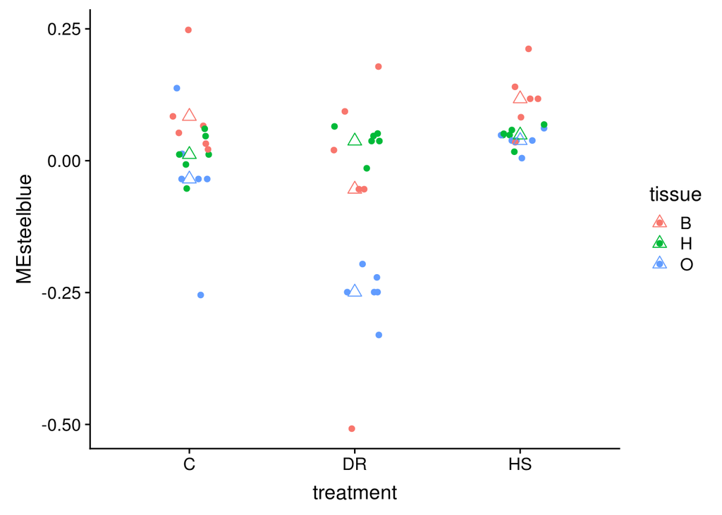

```r
all.plots[[19]]
```

```r
aov.mod_steelblue <- aov(eg.genes[,"MEsteelblue"] ~ phenDat.sva$treatment* phenDat.sva$tissue)
summary(aov.mod_steelblue)
```

```
##                                          Df Sum Sq Mean Sq F value   Pr(>F)
## phenDat.sva$treatment                     2 0.2325 0.11624  11.746 7.86e-05 ***
## phenDat.sva$tissue                        2 0.1833 0.09163   9.258 0.000429 ***
## phenDat.sva$treatment:phenDat.sva$tissue  4 0.1389 0.03473   3.509 0.014126 *
## Residuals                                45 0.4454 0.00990
## ---
## Signif. codes:  0 '***' 0.001 '**' 0.01 '*' 0.05 '.' 0.1 ' ' 1
```

```r
steelblue_ph <- TukeyHSD(aov.mod_steelblue)
steelblue_ph
```

```
##   Tukey multiple comparisons of means
##     95% family-wise confidence level
##
## Fit: aov(formula = eg.genes[, "MEsteelblue"] ~ phenDat.sva$treatment * phenDat.sva$tissue)
##
## $`phenDat.sva$treatment`
##              diff         lwr         upr     p adj
## DR-C  -0.10904641 -0.18941543 -0.02867738 0.0054623
## HS-C   0.04772946 -0.03263957  0.12809848 0.3297150
## HS-DR  0.15677587  0.07640684  0.23714489 0.0000663
##
## $`phenDat.sva$tissue`
##            diff         lwr         upr     p adj
## H-B -0.01656535 -0.09693438  0.06380367 0.8718931
## O-B -0.13102453 -0.21139356 -0.05065551 0.0007799
## O-H -0.11445918 -0.19482820 -0.03409015 0.0034397
##
## $`phenDat.sva$treatment:phenDat.sva$tissue`
##                   diff         lwr          upr     p adj
## DR:B-C:B  -0.138120596 -0.32519818  0.048956991 0.3064041
## HS:B-C:B   0.033288044 -0.15378954  0.220365630 0.9996317
## C:H-C:B   -0.072308959 -0.25938655  0.114768628 0.9378532
## DR:H-C:B  -0.046826493 -0.23390408  0.140251094 0.9958083
## HS:H-C:B  -0.035393163 -0.22247075  0.151684424 0.9994222
## C:O-C:B   -0.118796529 -0.30587412  0.068281057 0.5066129
## DR:O-C:B  -0.333297625 -0.52037521 -0.146220038 0.0000205
## HS:O-C:B  -0.045811998 -0.23288959  0.141265588 0.9963915
## HS:B-DR:B  0.171408639 -0.01566895  0.358486226 0.0959758
## C:H-DR:B   0.065811637 -0.12126595  0.252889224 0.9634464
## DR:H-DR:B  0.091294103 -0.09578348  0.278371689 0.8053080
## HS:H-DR:B  0.102727433 -0.08435015  0.289805020 0.6890827
## C:O-DR:B   0.019324066 -0.16775352  0.206401653 0.9999941
## DR:O-DR:B -0.195177029 -0.38225462 -0.008099442 0.0349212
## HS:O-DR:B  0.092308597 -0.09476899  0.279386184 0.7958958
## C:H-HS:B  -0.105597002 -0.29267459  0.081480584 0.6572389
## DR:H-HS:B -0.080114537 -0.26719212  0.106963050 0.8939157
## HS:H-HS:B -0.068681206 -0.25575879  0.118396380 0.9533001
## C:O-HS:B  -0.152084573 -0.33916216  0.034993014 0.1962408
## DR:O-HS:B -0.366585668 -0.55366326 -0.179508082 0.0000029
## HS:O-HS:B -0.079100042 -0.26617763  0.107977545 0.9004763
## DR:H-C:H   0.025482465 -0.16159512  0.212560052 0.9999506
## HS:H-C:H   0.036915796 -0.15016179  0.223993383 0.9992151
## C:O-C:H   -0.046487571 -0.23356516  0.140590016 0.9960110
## DR:O-C:H  -0.260988666 -0.44806625 -0.073911079 0.0012618
## HS:O-C:H   0.026496960 -0.16058063  0.213574547 0.9999334
## HS:H-DR:H  0.011433330 -0.17564426  0.198510917 0.9999999
## C:O-DR:H  -0.071970036 -0.25904762  0.115107551 0.9394256
## DR:O-DR:H -0.286471131 -0.47354872 -0.099393545 0.0003059
## HS:O-DR:H  0.001014495 -0.18606309  0.188092081 1.0000000
## C:O-HS:H  -0.083403366 -0.27048095  0.103674220 0.8709022
## DR:O-HS:H -0.297904462 -0.48498205 -0.110826875 0.0001596
## HS:O-HS:H -0.010418836 -0.19749642  0.176658751 1.0000000
## DR:O-C:O  -0.214501095 -0.40157868 -0.027423509 0.0140842
## HS:O-C:O   0.072984531 -0.11409306  0.260062118 0.9346378
## HS:O-DR:O  0.287485626  0.10040804  0.474563213 0.0002888
```

```r
subset(screenTab,screenTab$module=="steelblue")
```

```
##        module size   p-val  Bonf nInTerm ont                               term name
## 181 steelblue   44 3.0e-06 0.025       3  BP protein localization to Golgi apparatus
## 182 steelblue   44 2.4e-05 0.200      27  CC                               cytoplasm
## 183 steelblue   44 3.6e-05 0.300       9  BP              regulation of localization
## 184 steelblue   44 4.4e-05 0.370       2  BP    protein retention in Golgi apparatus
## 185 steelblue   44 1.4e-04 1.000       7  BP                          cell migration
## 186 steelblue   44 1.5e-04 1.000       2  BP                perineurial glial growth
## 187 steelblue   44 1.7e-04 1.000       4  BP            regulation of cell migration
## 188 steelblue   44 1.9e-04 1.000      19  MF                         protein binding
## 189 steelblue   44 2.2e-04 1.000       6  BP            muscle structure development
## 190 steelblue   44 2.5e-04 1.000       3  BP maintenance of protein location in cell
```

44 genes Tissue*** treatment*** interaction* high, low, high; larger effect in ovaries Treatment highly sig in DR-C and HS-DR, insig in HS-C Tissue sig for O-B and O-H only Interaction highly sig in 8 diet-tissue comparisons GO: protein localization and binding

## Tan module

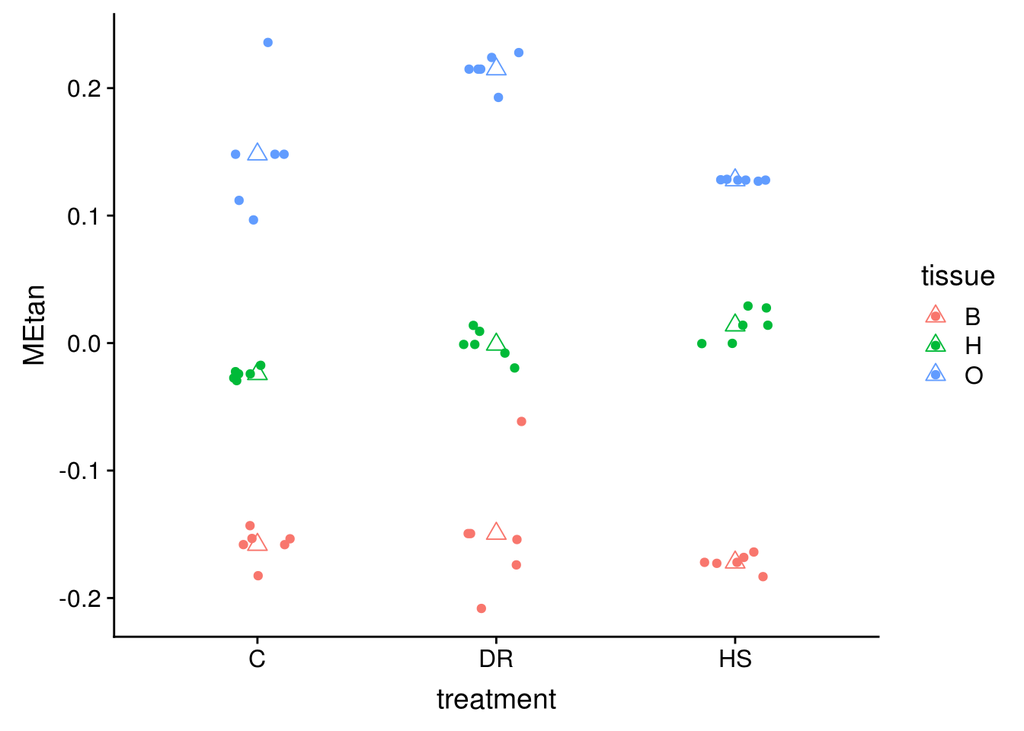

```r
all.plots[[20]]
```

```r
aov.mod_tan <- aov(eg.genes[,"MEtan"] ~ phenDat.sva$treatment* phenDat.sva$tissue)
summary(aov.mod_tan)
```

```
##                                          Df Sum Sq Mean Sq F value   Pr(>F)
## phenDat.sva$treatment                     2 0.0124  0.0062  10.404 0.000193 ***
## phenDat.sva$tissue                        2 0.9422  0.4711 787.930  < 2e-16 ***
## phenDat.sva$treatment:phenDat.sva$tissue  4 0.0184  0.0046   7.707 8.08e-05 ***
## Residuals                                45 0.0269  0.0006
## ---
## Signif. codes:  0 '***' 0.001 '**' 0.01 '*' 0.05 '.' 0.1 ' ' 1
```

```r
tan_ph <- TukeyHSD(aov.mod_tan)
tan_ph
```

```
##   Tukey multiple comparisons of means
##     95% family-wise confidence level
##
## Fit: aov(formula = eg.genes[, "MEtan"] ~ phenDat.sva$treatment * phenDat.sva$tissue)
##
## $`phenDat.sva$treatment`
##               diff         lwr         upr     p adj
## DR-C   0.032847709  0.01309351  0.05260191 0.0006119
## HS-C   0.001337788 -0.01841641  0.02109199 0.9852632
## HS-DR -0.031509921 -0.05126412 -0.01175572 0.0010114
##
## $`phenDat.sva$tissue`
##          diff       lwr       upr p adj
## H-B 0.1561178 0.1363636 0.1758720     0
## O-B 0.3234947 0.3037405 0.3432489     0
## O-H 0.1673769 0.1476227 0.1871311     0
##
## $`phenDat.sva$treatment:phenDat.sva$tissue`
##                   diff          lwr         upr     p adj
## DR:B-C:B   0.008681917 -0.037300582  0.05466441 0.9994307
## HS:B-C:B  -0.013886844 -0.059869342  0.03209565 0.9855610
## C:H-C:B    0.133958866  0.087976368  0.17994136 0.0000000
## DR:H-C:B   0.157060424  0.111077926  0.20304292 0.0000000
## HS:H-C:B   0.172129235  0.126146737  0.21811173 0.0000000
## C:O-C:B    0.306263226  0.260280728  0.35224572 0.0000000
## DR:O-C:B   0.373022879  0.327040381  0.41900538 0.0000000
## HS:O-C:B   0.285993064  0.240010566  0.33197556 0.0000000
## HS:B-DR:B -0.022568761 -0.068551259  0.02341374 0.8004553
## C:H-DR:B   0.125276950  0.079294451  0.17125945 0.0000000
## DR:H-DR:B  0.148378508  0.102396009  0.19436101 0.0000000
## HS:H-DR:B  0.163447319  0.117464820  0.20942982 0.0000000
## C:O-DR:B   0.297581310  0.251598811  0.34356381 0.0000000
## DR:O-DR:B  0.364340963  0.318358464  0.41032346 0.0000000
## HS:O-DR:B  0.277311148  0.231328650  0.32329365 0.0000000
## C:H-HS:B   0.147845710  0.101863212  0.19382821 0.0000000
## DR:H-HS:B  0.170947268  0.124964770  0.21692977 0.0000000
## HS:H-HS:B  0.186016079  0.140033581  0.23199858 0.0000000
## C:O-HS:B   0.320150070  0.274167572  0.36613257 0.0000000
## DR:O-HS:B  0.386909723  0.340927225  0.43289222 0.0000000
## HS:O-HS:B  0.299879908  0.253897410  0.34586241 0.0000000
## DR:H-C:H   0.023101558 -0.022880940  0.06908406 0.7798789
## HS:H-C:H   0.038170369 -0.007812129  0.08415287 0.1755750
## C:O-C:H    0.172304360  0.126321862  0.21828686 0.0000000
## DR:O-C:H   0.239064013  0.193081515  0.28504651 0.0000000
## HS:O-C:H   0.152034198  0.106051700  0.19801670 0.0000000
## HS:H-DR:H  0.015068811 -0.030913687  0.06105131 0.9760276
## C:O-DR:H   0.149202802  0.103220304  0.19518530 0.0000000
## DR:O-DR:H  0.215962455  0.169979957  0.26194495 0.0000000
## HS:O-DR:H  0.128932640  0.082950142  0.17491514 0.0000000
## C:O-HS:H   0.134133991  0.088151493  0.18011649 0.0000000
## DR:O-HS:H  0.200893644  0.154911146  0.24687614 0.0000000
## HS:O-HS:H  0.113863829  0.067881331  0.15984633 0.0000000
## DR:O-C:O   0.066759653  0.020777155  0.11274215 0.0007034
## HS:O-C:O  -0.020270162 -0.066252660  0.02571234 0.8777157
## HS:O-DR:O -0.087029815 -0.133012313 -0.04104732 0.0000060
```

```r
subset(screenTab,screenTab$module=="tan")
```

```
##     module size   p-val Bonf nInTerm ont                                term name
## 191    tan  163 3.3e-05 0.27      19  BP               vesicle-mediated transport
## 192    tan  163 4.0e-05 0.34       4  CC    AP-type membrane coat adaptor complex
## 193    tan  163 1.1e-04 0.92       4  BP          ommochrome biosynthetic process
## 194    tan  163 1.1e-04 0.92       4  BP     ocellus pigment biosynthetic process
## 195    tan  163 2.0e-04 1.00       3  BP chromatin-mediated maintenance of transc
## 196    tan  163 2.5e-04 1.00       6  MF             protein transporter activity
## 197    tan  163 5.4e-04 1.00       6  CC  small nuclear ribonucleoprotein complex
## 198    tan  163 8.6e-04 1.00      15  CC                              nucleoplasm
## 199    tan  163 1.1e-03 1.00       2  CC                     AP-3 adaptor complex
## 200    tan  163 1.5e-03 1.00      28  BP    cellular protein modification process
```

163 genes Tissue*** treatment*** interaction*** Treatment highly sig in DR-C and HS-DR, insig in HS-C Tissue highly sig for all comparisons Interaction highly sig in 29 diet-tissue comparisons (O low, high, low; larger effect in ovaries) GO: pigment biosynthesis

## Turquoise module

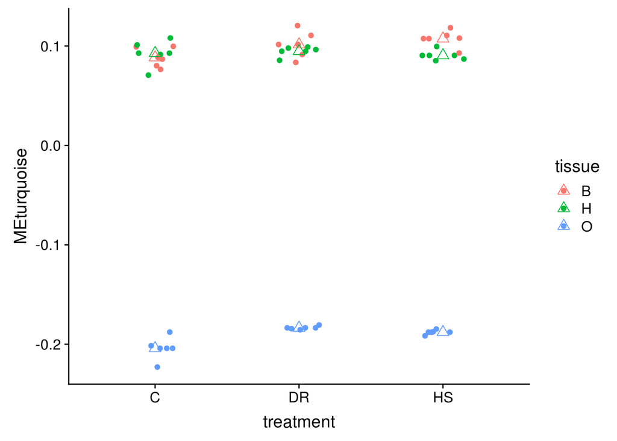

```r
all.plots[[21]]
```

```r
aov.mod_turquoise <- aov(eg.genes[,"MEturquoise"] ~ phenDat.sva$treatment* phenDat.sva$tissue)
summary(aov.mod_turquoise)
```

```
##                                          Df Sum Sq Mean Sq F value   Pr(>F)
## phenDat.sva$treatment                     2 0.0016  0.0008   10.54 0.000176 ***
## phenDat.sva$tissue                        2 0.9940  0.4970 6667.17  < 2e-16 ***
## phenDat.sva$treatment:phenDat.sva$tissue  4 0.0010  0.0003    3.44 0.015493 *
## Residuals                                45 0.0034  0.0001
## ---
## Signif. codes:  0 '***' 0.001 '**' 0.01 '*' 0.05 '.' 0.1 ' ' 1
```

```r
turquoise_ph <- TukeyHSD(aov.mod_turquoise)
turquoise_ph
```

```
##   Tukey multiple comparisons of means
##     95% family-wise confidence level
##
## Fit: aov(formula = eg.genes[, "MEturquoise"] ~ phenDat.sva$treatment * phenDat.sva$tissue)
##
## $`phenDat.sva$treatment`
##                diff          lwr         upr     p adj
## DR-C   0.0118617095  0.004886456 0.018836964 0.0004608
## HS-C   0.0109703389  0.003995085 0.017945593 0.0011914
## HS-DR -0.0008913707 -0.007866625 0.006083883 0.9485583
##
## $`phenDat.sva$tissue`
##             diff        lwr           upr     p adj
## H-B -0.006437247 -0.0134125  0.0005380067 0.0758465
## O-B -0.290979455 -0.2979547 -0.2840042013 0.0000000
## O-H -0.284542208 -0.2915175 -0.2775669540 0.0000000
##
## $`phenDat.sva$treatment:phenDat.sva$tissue`
##                   diff           lwr           upr     p adj
## DR:B-C:B   0.013066030 -3.170495e-03  0.0293025552 0.2067507
## HS:B-C:B   0.018977931  2.741406e-03  0.0352144564 0.0114839
## C:H-C:B    0.004360846 -1.187568e-02  0.0205973714 0.9932614
## DR:H-C:B   0.006286794 -9.949731e-03  0.0225233193 0.9372541
## HS:H-C:B   0.002084579 -1.415195e-02  0.0183211040 0.9999686
## C:O-C:B   -0.292565636 -3.088022e-01 -0.2763291109 0.0000000
## DR:O-C:B  -0.271972485 -2.882090e-01 -0.2557359603 0.0000000
## HS:O-C:B  -0.276356283 -2.925928e-01 -0.2601197581 0.0000000
## HS:B-DR:B  0.005911901 -1.032462e-02  0.0221484262 0.9554348
## C:H-DR:B  -0.008705184 -2.494171e-02  0.0075313413 0.7153528
## DR:H-DR:B -0.006779236 -2.301576e-02  0.0094572892 0.9066296
## HS:H-DR:B -0.010981451 -2.721798e-02  0.0052550738 0.4212983
## C:O-DR:B  -0.305631666 -3.218682e-01 -0.2893951410 0.0000000
## DR:O-DR:B -0.285038516 -3.012750e-01 -0.2688019905 0.0000000
## HS:O-DR:B -0.289422313 -3.056588e-01 -0.2731857883 0.0000000
## C:H-HS:B  -0.014617085 -3.085361e-02  0.0016194402 0.1079421
## DR:H-HS:B -0.012691137 -2.892766e-02  0.0035453880 0.2384258
## HS:H-HS:B -0.016893352 -3.312988e-02 -0.0006568273 0.0357684
## C:O-HS:B  -0.311543567 -3.277801e-01 -0.2953070422 0.0000000
## DR:O-HS:B -0.290950417 -3.071869e-01 -0.2747138916 0.0000000
## HS:O-HS:B -0.295334215 -3.115707e-01 -0.2790976894 0.0000000
## DR:H-C:H   0.001925948 -1.431058e-02  0.0181624730 0.9999829
## HS:H-C:H  -0.002276267 -1.851279e-02  0.0139602576 0.9999384
## C:O-C:H   -0.296926482 -3.131630e-01 -0.2806899572 0.0000000
## DR:O-C:H  -0.276333332 -2.925699e-01 -0.2600968067 0.0000000
## HS:O-C:H  -0.280717130 -2.969537e-01 -0.2644806045 0.0000000
## HS:H-DR:H -0.004202215 -2.043874e-02  0.0120343097 0.9947423
## C:O-DR:H  -0.298852430 -3.150890e-01 -0.2826159051 0.0000000
## DR:O-DR:H -0.278259280 -2.944958e-01 -0.2620227546 0.0000000
## HS:O-DR:H -0.282643077 -2.988796e-01 -0.2664065524 0.0000000
## C:O-HS:H  -0.294650215 -3.108867e-01 -0.2784136898 0.0000000
## DR:O-HS:H -0.274057064 -2.902936e-01 -0.2578205392 0.0000000
## HS:O-HS:H -0.278440862 -2.946774e-01 -0.2622043370 0.0000000
## DR:O-C:O   0.020593151  4.356625e-03  0.0368296756 0.0044687
## HS:O-C:O   0.016209353 -2.717233e-05  0.0324458778 0.0506842
## HS:O-DR:O -0.004383798 -2.062032e-02  0.0118527273 0.9930221
```

```r
subset(screenTab,screenTab$module=="turquoise")
```

```
##        module size   p-val    Bonf nInTerm ont                         term name
## 201 turquoise 3337 9.6e-48 8.0e-44     403  CC              extracellular region
## 202 turquoise 3337 6.3e-36 5.3e-32     237  CC               extracellular space
## 203 turquoise 3337 2.1e-34 1.8e-30     257  BP       oxidation-reduction process
## 204 turquoise 3337 7.0e-34 5.9e-30     262  MF           oxidoreductase activity
## 205 turquoise 3337 1.4e-20 1.1e-16     167  MF                  cofactor binding
## 206 turquoise 3337 2.1e-18 1.7e-14     108  BP             response to bacterium
## 207 turquoise 3337 7.3e-17 6.1e-13      83  MF                  iron ion binding
## 208 turquoise 3337 5.7e-16 4.8e-12     168  BP carboxylic acid metabolic process
## 209 turquoise 3337 9.2e-16 7.7e-12     155  BP                  defense response
## 210 turquoise 3337 1.0e-15 8.7e-12     173  BP    organic acid metabolic process
```

## White module

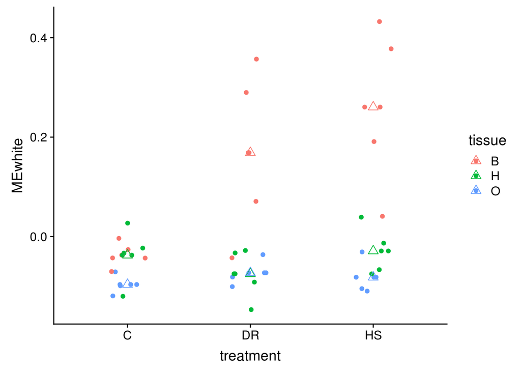

```r
all.plots[[22]]
```

```r
aov.mod_white <- aov(eg.genes[,"MEwhite"] ~ phenDat.sva$treatment* phenDat.sva$tissue)
summary(aov.mod_white)
```

```
##                                          Df Sum Sq Mean Sq F value   Pr(>F)
## phenDat.sva$treatment                     2 0.1042 0.05210   9.794 0.000294 ***
## phenDat.sva$tissue                        2 0.4729 0.23646  44.449 2.21e-11 ***
## phenDat.sva$treatment:phenDat.sva$tissue  4 0.1835 0.04588   8.624 2.96e-05 ***
## Residuals                                45 0.2394 0.00532
## ---
## Signif. codes:  0 '***' 0.001 '**' 0.01 '*' 0.05 '.' 0.1 ' ' 1
```

```r
white_ph <- TukeyHSD(aov.mod_white)
white_ph
```

```
##   Tukey multiple comparisons of means
##     95% family-wise confidence level
##
## Fit: aov(formula = eg.genes[, "MEwhite"] ~ phenDat.sva$treatment * phenDat.sva$tissue)
##
## $`phenDat.sva$treatment`
##             diff          lwr       upr     p adj
## DR-C  0.06401433  0.005091337 0.1229373 0.0304722
## HS-C  0.10690756  0.047984566 0.1658305 0.0001929
## HS-DR 0.04289323 -0.016029763 0.1018162 0.1931992
##
## $`phenDat.sva$tissue`
##            diff         lwr         upr     p adj
## H-B -0.17767615 -0.23659914 -0.11875316 0.0000000
## O-B -0.21426847 -0.27319147 -0.15534548 0.0000000
## O-H -0.03659233 -0.09551532  0.02233066 0.2981726
##
## $`phenDat.sva$treatment:phenDat.sva$tissue`
##                    diff         lwr         upr     p adj
## DR:B-C:B   0.2059039314  0.06874697  0.34306089 0.0004200
## HS:B-C:B   0.2976607389  0.16050378  0.43481770 0.0000003
## C:H-C:B   -0.0001382515 -0.13729521  0.13701871 1.0000000
## DR:H-C:B  -0.0376087160 -0.17476568  0.09954824 0.9922703
## HS:H-C:B   0.0082831976 -0.12887376  0.14544016 0.9999999
## C:O-C:B   -0.0591635854 -0.19632055  0.07799337 0.8900325
## DR:O-C:B  -0.0355540664 -0.17271103  0.10160289 0.9946860
## HS:O-C:B  -0.0445231008 -0.18168006  0.09263386 0.9773729
## HS:B-DR:B  0.0917568076 -0.04540015  0.22891377 0.4360774
## C:H-DR:B  -0.2060421829 -0.34319914 -0.06888522 0.0004156
## DR:H-DR:B -0.2435126473 -0.38066961 -0.10635569 0.0000219
## HS:H-DR:B -0.1976207338 -0.33477769 -0.06046377 0.0007884
## C:O-DR:B  -0.2650675168 -0.40222448 -0.12791056 0.0000039
## DR:O-DR:B -0.2414579977 -0.37861496 -0.10430104 0.0000258
## HS:O-DR:B -0.2504270322 -0.38758399 -0.11327007 0.0000126
## C:H-HS:B  -0.2977989904 -0.43495595 -0.16064203 0.0000003
## DR:H-HS:B -0.3352694549 -0.47242641 -0.19811250 0.0000000
## HS:H-HS:B -0.2893775414 -0.42653450 -0.15222058 0.0000005
## C:O-HS:B  -0.3568243243 -0.49398128 -0.21966736 0.0000000
## DR:O-HS:B -0.3332148053 -0.47037177 -0.19605785 0.0000000
## HS:O-HS:B -0.3421838397 -0.47934080 -0.20502688 0.0000000
## DR:H-C:H  -0.0374704645 -0.17462742  0.09968650 0.9924560
## HS:H-C:H   0.0084214491 -0.12873551  0.14557841 0.9999999
## C:O-C:H   -0.0590253339 -0.19618229  0.07813163 0.8912984
## DR:O-C:H  -0.0354158149 -0.17257277  0.10174114 0.9948238
## HS:O-C:H  -0.0443848493 -0.18154181  0.09277211 0.9777989
## HS:H-DR:H  0.0458919135 -0.09126505  0.18304887 0.9728200
## C:O-DR:H  -0.0215548695 -0.15871183  0.11560209 0.9998540
## DR:O-DR:H  0.0020546496 -0.13510231  0.13921161 1.0000000
## HS:O-DR:H -0.0069143849 -0.14407134  0.13024257 1.0000000
## C:O-HS:H  -0.0674467830 -0.20460374  0.06971018 0.7988254
## DR:O-HS:H -0.0438372639 -0.18099422  0.09331970 0.9794273
## HS:O-HS:H -0.0528062984 -0.18996326  0.08435066 0.9391675
## DR:O-C:O   0.0236095191 -0.11354744  0.16076648 0.9997118
## HS:O-C:O   0.0146404846 -0.12251648  0.15179744 0.9999924
## HS:O-DR:O -0.0089690345 -0.14612599  0.12818793 0.9999998
```

```r
subset(screenTab,screenTab$module=="white")
```

```
##     module size   p-val    Bonf nInTerm ont                                term name
## 211  white   54 5.8e-30 4.8e-26      19  MF structural constituent of chitin-based c
## 212  white   54 2.0e-29 1.7e-25      19  MF        structural constituent of cuticle
## 213  white   54 7.4e-27 6.2e-23      20  CC                     extracellular matrix
## 214  white   54 1.3e-25 1.1e-21      19  BP         chitin-based cuticle development
## 215  white   54 2.2e-22 1.8e-18      19  BP                      cuticle development
## 216  white   54 2.0e-20 1.6e-16      26  CC                     extracellular region
## 217  white   54 1.6e-19 1.4e-15      13  MF structural constituent of chitin-based l
## 218  white   54 2.1e-18 1.8e-14      20  MF             structural molecule activity
## 219  white   54 5.0e-09 4.2e-05       5  BP                       body morphogenesis
## 220  white   54 2.2e-05 1.8e-01      20  BP       multicellular organism development
```